# Asymmetric alignment paper, analysis and graphs on combined data

Kenny Smith

There are a small number of focussed questions where we want to look at data from both experiments. The point here is just to reiterate that individuals paired with categorical participants change more than categorical participants.

For all the analyses that follow, the question is: Do variable participants paired with categorical participants change differently from variable paired with variable?

# Read in data and report Ns

```r
exp1.data <- read.csv("ProcessedData/Experiment1Data.csv")
exp2.data <- read.csv("ProcessedData/Experiment2Data.csv")

combined.data <- rbind(exp1.data,exp2.data)

plyr::ddply(combined.data,~Condition,plyr::summarise,Current_N=length(unique(Pair)))
```

```
##   Condition Current_N
## 1     66-33        20
## 2     83-17        20
## 3    100-33        21
## 4    100-66        20
```

# Data processing

Need to calculate block-to-block change.

```r
combined.data.singulars <- subset(combined.data,Number==1)
combined.data.by.block <- aggregate(data=combined.data.singulars,
                                       Marked~Condition + Pair + Block + Participant + ParticipantID,
                                       FUN=mean)

combined.data.by.block <- plyr::rename(combined.data.by.block,c("Marked"="ProportionMarkedSingulars"))


#The most convenient way to calculate differences from block to block is to restructure the data to wide format.
combined.change.data <- tidyr::spread(data=combined.data.by.block,Block,ProportionMarkedSingulars)

combined.change.data$ChangeTrainingRecall1 <- combined.change.data$'Recall 1' - combined.change.data$'Training'

combined.change.data$ChangeRecall1Interaction2 <- combined.change.data$'Interaction Block 2'-combined.change.data$'Recall 1'

combined.change.data$ChangeRecall1Recall2 <- combined.change.data$'Recall 2'-combined.change.data$'Recall 1'

#utility function to label trials
classify.combination <- function(Condition,Participant){
  if ((Condition=="100-66" | Condition=="100-33") & Participant=="P1") {
    "Categorical"}
  else if ((Condition=="100-66" | Condition=="100-33") & Participant=="P2") {
    "Experiment 2:\nVariable paired\nwith Categorical"}
  else {"Experiment 1:\nVariable paired\nwith Variable"}
}

combined.change.data$CombinationCondition <- mapply(classify.combination,combined.change.data$Condition,combined.change.data$Participant)
#order levels the way I want
combined.change.data$CombinationCondition <- factor(combined.change.data$CombinationCondition,
                                               levels=c("Categorical",
                                                        "Experiment 1:\nVariable paired\nwith Variable",
                                                        "Experiment 2:\nVariable paired\nwith Categorical"))
```

# Looking at all data

Plot.

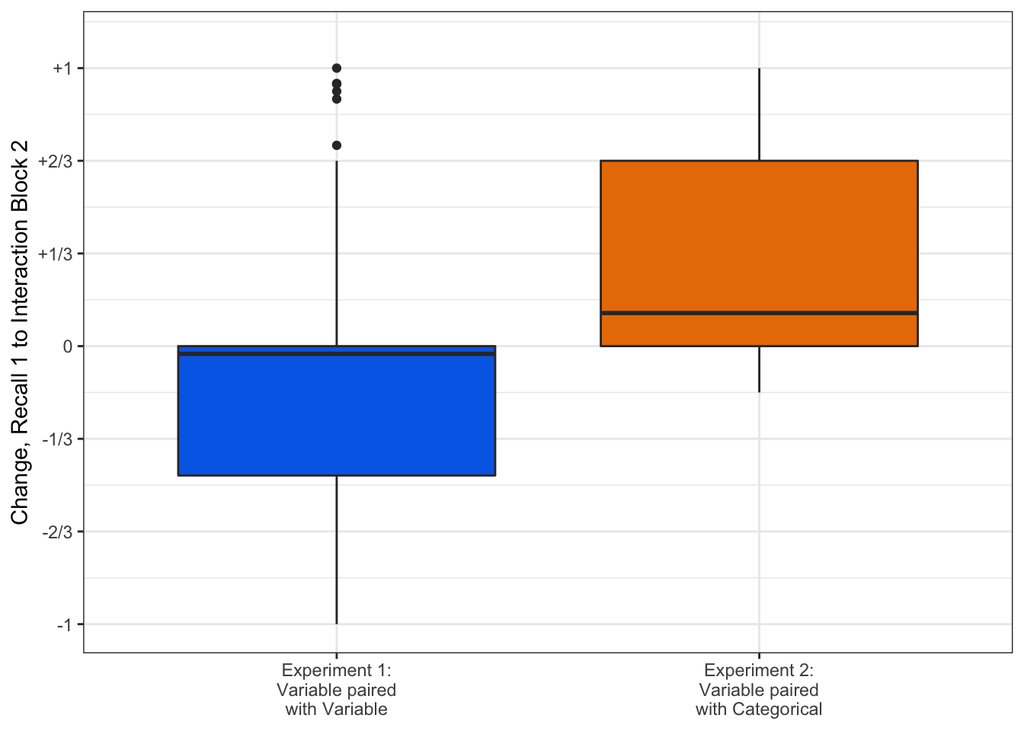

```r
ggplot(data=subset(combined.change.data,CombinationCondition!="Categorical"), aes(x=CombinationCondition, y=ChangeRecall1Interaction2, fill=CombinationCondition,ymin=-1)) +
  theme_bw() +
  geom_boxplot() +
  scale_fill_manual(values=c(my.colours[2],my.colours[1])) +
  scale_y_continuous(limits=c(-1,1.1),breaks=seq(-1,1,1/3),labels=c("-1","-2/3","-1/3","0","+1/3","+2/3","+1")) +
  ylab("Change, Recall 1 to Interaction Block 2") +
  theme(axis.title.x = element_blank()) +
  #theme(strip.text.y = element_blank()) +
  theme(legend.position="none")
```

Statistic: **Yes**, they differ.

```r
wilcox.test(subset(combined.change.data,CombinationCondition=="Experiment 2:\nVariable paired\nwith Categorical")$ChangeRecall1Interaction2,
            subset(combined.change.data,CombinationCondition=="Experiment 1:\nVariable paired\nwith Variable")$ChangeRecall1Interaction2)
```

```
##
##  Wilcoxon rank sum test with continuity correction
##
## data:  subset(combined.change.data, CombinationCondition == "Experiment 2:\nVariable paired\nwith Categorical")$ChangeRecall1Interaction2 and subset(combined.change.data, CombinationCondition == "Experiment 1:\nVariable paired\nwith Variable")$ChangeRecall1Interaction2
## W = 2478.5, p-value = 3.795e-06
## alternative hypothesis: true location shift is not equal to 0
```

# Looking only at P2s

Running the analysis on P2s only provides a tighter comparison since they are all paired with a more frequent user. **Difference is still significant**.

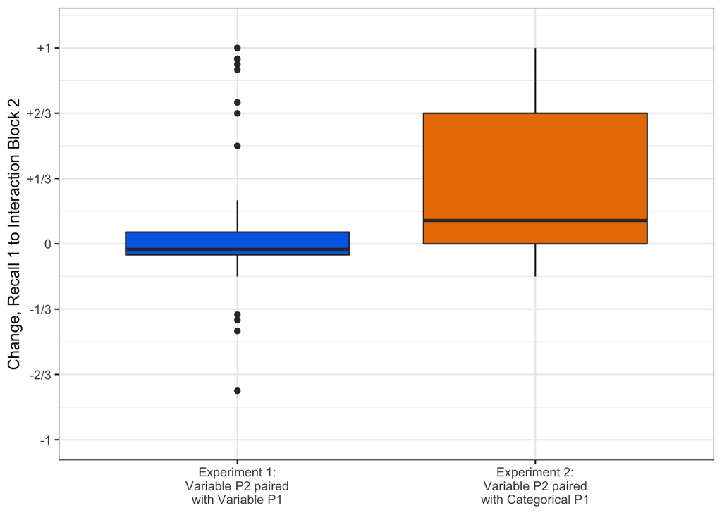

```r
ggplot(data=subset(combined.change.data,CombinationCondition!="Categorical" & Participant=="P2"), aes(x=CombinationCondition, y=ChangeRecall1Interaction2, fill=CombinationCondition),ymin=-1) +
  theme_bw() +
  geom_boxplot() +
  #facet_grid(StageToStage~Condition,drop = TRUE) +
  scale_fill_manual(values=c(my.colours[2],my.colours[1])) +
  scale_x_discrete(labels=c("Experiment 1:\nVariable P2 paired\nwith Variable P1",
                            "Experiment 2:\nVariable P2 paired\nwith Categorical P1")) +
  scale_y_continuous(limits=c(-1,1.1),breaks=seq(-1,1,1/3),labels=c("-1","-2/3","-1/3","0","+1/3","+2/3","+1")) +
  ylab("Change, Recall 1 to Interaction Block 2") +
  theme(axis.title.x = element_blank()) +
  #theme(strip.text.y = element_blank()) +
  theme(legend.position="none") +
  expand_limits(y=-1)
```

```r
wilcox.test(subset(combined.change.data,CombinationCondition=="Experiment 2:\nVariable paired\nwith Categorical" & Participant=="P2")$ChangeRecall1Interaction2,
            subset(combined.change.data,CombinationCondition=="Experiment 1:\nVariable paired\nwith Variable"& Participant=="P2")$ChangeRecall1Interaction2)
```

```
##
##  Wilcoxon rank sum test with continuity correction
##
## data:  subset(combined.change.data, CombinationCondition == "Experiment 2:\nVariable paired\nwith Categorical" &  and subset(combined.change.data, CombinationCondition == "Experiment 1:\nVariable paired\nwith Variable" &     Participant == "P2")$ChangeRecall1Interaction2 and     Participant == "P…
## W = 1123, p-value = 0.004093
## alternative hypothesis: true location shift is not equal to 0
```

# Looking only at 33% trained participants

Since we have 33%-trained participants in both experiments we can compare these. Answer is **yes**, they still differ based on whether their partner was categorical or variable.

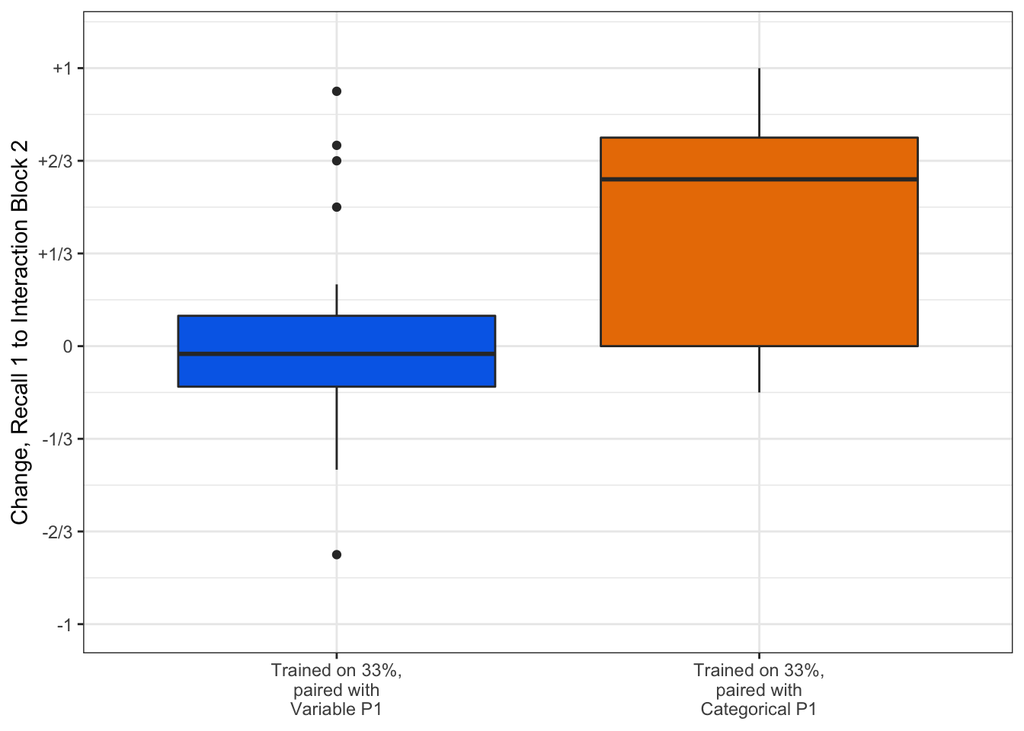

```r
ggplot(data=subset(combined.change.data,(Condition=="100-33" & Participant=="P2") | (Condition=="66-33" & Participant=="P2")), aes(x=CombinationCondition, y=ChangeRecall1Interaction2, fill=CombinationCondition)) +
  theme_bw() +
  geom_boxplot() +
  #facet_grid(StageToStage~Condition,drop = TRUE) +
  scale_fill_manual(values=c(my.colours[2],my.colours[1])) +
  scale_x_discrete(labels=c("Trained on 33%,\npaired with\nVariable P1",
                            "Trained on 33%,\npaired with\nCategorical P1")) +
  scale_y_continuous(limits=c(-1,1.1),breaks=seq(-1,1,1/3),labels=c("-1","-2/3","-1/3","0","+1/3","+2/3","+1")) +
  ylab("Change, Recall 1 to Interaction Block 2") +
  theme(axis.title.x = element_blank()) +
  #theme(strip.text.y = element_blank()) +
  theme(legend.position="none")
```

```r
wilcox.test(subset(combined.change.data,(Condition=="100-33" & Participant=="P2"))$ChangeRecall1Interaction2,
            subset(combined.change.data,(Condition=="66-33" & Participant=="P2"))$ChangeRecall1Interaction2)
```

```
##
##  Wilcoxon rank sum test with continuity correction
##
## data:  subset(combined.change.data, (Condition == "100-33" & Participant ==  and subset(combined.change.data, (Condition == "66-33" & Participant ==     "P2"))$ChangeRecall1Interaction2 and     "P2"))$ChangeRecall1Interaction2
## W = 311, p-value = 0.00867
## alternative hypothesis: true location shift is not equal to 0
```

# Analysis looking at participants who were categorical at Recall 1

Finally, it might be that the relevant measure of categoricalness is not their training, but what a participant produced at Recall 1. Do variably-trained participants who were categorical users at Recall 1 look like categorical participants in terms of their willingness to change? Note that we are including only categorical users in this analysis.

```r
combined.change.data$CategoricalAtTraining <- combined.change.data$Training==1
#This would be on the categorical users + non-users, but I think the latter are not quite comparable
#combined.change.data$CategoricalAtRecall1 <- (combined.change.data$'Recall 1'==1 | combined.change.data$'Recall 1'==0)
combined.change.data$CategoricalAtRecall1 <- (combined.change.data$'Recall 1'==1)

#useful for qualitative observations
combined.change.data$CategoricalUserAtInteraction2 <- (combined.change.data$'Interaction Block 2'==1)
combined.change.data$CategoricalNonUserAtInteraction2 <- (combined.change.data$'Interaction Block 2'==0)
combined.change.data$NotCategoricalUserAtInteraction2 <- (combined.change.data$'Interaction Block 2'<1)

plyr::ddply(combined.change.data,~Condition+CategoricalAtTraining+CategoricalAtRecall1,plyr::summarise,Current_N=length(unique(ParticipantID)))
```

```
##    Condition CategoricalAtTraining CategoricalAtRecall1 Current_N
## 1      66-33                 FALSE                FALSE        34
## 2      66-33                 FALSE                 TRUE         6
## 3      83-17                 FALSE                FALSE        31
## 4      83-17                 FALSE                 TRUE         9
## 5     100-33                 FALSE                FALSE        21
## 6     100-33                  TRUE                 TRUE        21
## 7     100-66                 FALSE                FALSE        13
## 8     100-66                 FALSE                 TRUE         7
## 9     100-66                  TRUE                FALSE         1
## 10    100-66                  TRUE                 TRUE        19
```

```r
combined.change.data.categorical.recall1 <- subset(combined.change.data,CategoricalAtRecall1)

plyr::ddply(combined.change.data.categorical.recall1,~CategoricalAtTraining+CategoricalAtRecall1,plyr::summarise,Current_N=length(unique(ParticipantID)))
```

```
##   CategoricalAtTraining CategoricalAtRecall1 Current_N
## 1                 FALSE                 TRUE        22
## 2                  TRUE                 TRUE        40
```

```r
#in the text we report what the variably-trained-but-categorical people did during interaction
#the subsetting is to restrict us to vartiably-trained participants
plyr::ddply(subset(combined.change.data,!CategoricalAtTraining & CategoricalAtRecall1), ~CategoricalUserAtInteraction2+CategoricalNonUserAtInteraction2+NotCategoricalUserAtInteraction2,plyr::summarise,Current_N=length(unique(ParticipantID)))
```

```
##   CategoricalUserAtInteraction2 CategoricalNonUserAtInteraction2
## 1                         FALSE                             TRUE
## 2                          TRUE                            FALSE
##   NotCategoricalUserAtInteraction2 Current_N
## 1                             TRUE         5
## 2                            FALSE        17
```

```r
#and here is the equivalent for categorically-trained participants
plyr::ddply(subset(combined.change.data,CategoricalAtTraining), ~CategoricalUserAtInteraction2+CategoricalNonUserAtInteraction2+NotCategoricalUserAtInteraction2,plyr::summarise,Current_N=length(unique(ParticipantID)))
```

```
##   CategoricalUserAtInteraction2 CategoricalNonUserAtInteraction2
## 1                         FALSE                            FALSE
## 2                         FALSE                             TRUE
## 3                          TRUE                            FALSE
##   NotCategoricalUserAtInteraction2 Current_N
## 1                             TRUE         3
## 2                             TRUE         2
## 3                            FALSE        36
```

Do the categorically-trained participants differ form the ones who happen to be categorical in Recall 1? **No**, they don’t.

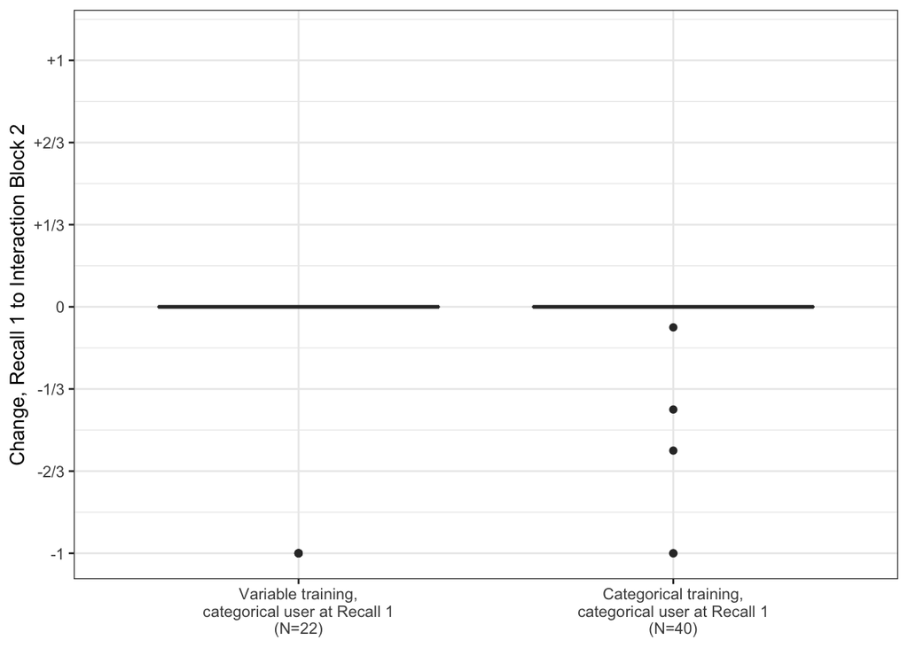

```r
ggplot(data=combined.change.data.categorical.recall1, aes(x=CategoricalAtTraining, y=ChangeRecall1Interaction2, fill=CategoricalAtTraining)) +
  theme_bw() +
  geom_boxplot() +
  scale_fill_manual(values=c(my.colours[2],my.colours[1])) +
  scale_x_discrete(labels=c("Variable training,\ncategorical user at Recall 1\n(N=22)",
                            "Categorical training,\ncategorical user at Recall 1\n(N=40)")) +
  scale_y_continuous(limits=c(-1,1.1),breaks=seq(-1,1,1/3),labels=c("-1","-2/3","-1/3","0","+1/3","+2/3","+1")) +
  ylab("Change, Recall 1 to Interaction Block 2") +
  theme(axis.title.x = element_blank()) +
  theme(legend.position="none")
```

```r
wilcox.test(subset(combined.change.data.categorical.recall1,CategoricalAtTraining)$ChangeRecall1Interaction2,
            subset(combined.change.data.categorical.recall1,!CategoricalAtTraining)$ChangeRecall1Interaction2)
```

```
##
##  Wilcoxon rank sum test with continuity correction
##
## data:  subset(combined.change.data.categorical.recall1, CategoricalAtTraining)$ChangeRecall1Interaction2 and subset(combined.change.data.categorical.recall1, !CategoricalAtTraining)$ChangeRecall1Interaction2
## W = 492.5, p-value = 0.2314
## alternative hypothesis: true location shift is not equal to 0
```

Can do same thing on the change from recall 1 to recall 2, but is it informative?

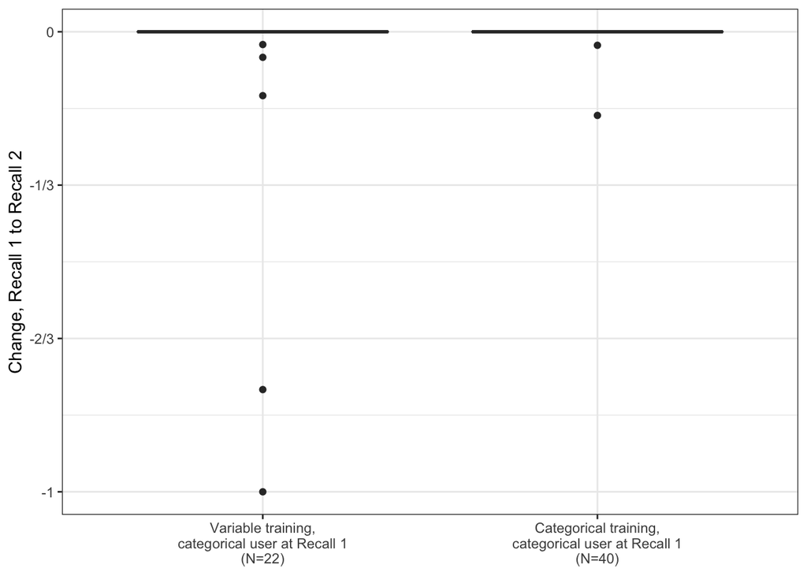

```r
ggplot(data=combined.change.data.categorical.recall1, aes(x=CategoricalAtTraining, y=ChangeRecall1Recall2, fill=CategoricalAtTraining)) +
  theme_bw() +
  geom_boxplot() +
  #facet_grid(StageToStage~Condition,drop = TRUE) +
  scale_fill_manual(values=c(my.colours[2],my.colours[1])) +
  scale_x_discrete(labels=c("Variable training,\ncategorical user at Recall 1\n(N=22)",
                            "Categorical training,\ncategorical user at Recall 1\n(N=40)")) +
  scale_y_continuous(breaks=seq(-1,1,1/3),labels=c("-1","-2/3","-1/3","0","+1/3","+2/3","+1")) +
  ylab("Change, Recall 1 to Recall 2") +
  theme(axis.title.x = element_blank()) +
  #theme(strip.text.y = element_blank()) +
  theme(legend.position="none") +
  expand_limits(y=-1)
```

```r
wilcox.test(subset(combined.change.data.categorical.recall1,CategoricalAtTraining)$ChangeRecall1Recall2,
            subset(combined.change.data.categorical.recall1,!CategoricalAtTraining)$ChangeRecall1Recall2)
```

```
##
##  Wilcoxon rank sum test with continuity correction
##
## data:  subset(combined.change.data.categorical.recall1, CategoricalAtTraining)$ChangeRecall1Recall2 and subset(combined.change.data.categorical.recall1, !CategoricalAtTraining)$ChangeRecall1Recall2
## W = 519, p-value = 0.03558
## alternative hypothesis: true location shift is not equal to 0
```